[figure not shown]

# Fewer dimensions: PCA and MCA

MY202 · Lab 7

Jonas Weinert

Department of Methodology | London School of Economics and Political Science

12 November 2026

## Lab overview

| Part | Topic | Notebook | Mode | Time |
| --- | --- | --- | --- | --- |
|  | Setup, and why fewer dimensions | lines 25–53 | together | 7 min |
| I | **PCA**: the school report, then 24 ability tests | lines 55–214 | concept → run together → your turn, twice | 40 min |
| II | **MCA**: what do you watch, then 19 moral questions | lines 216–291 | concept → run together → your turn | 26 min |
|  | Wrap-up: PCA or MCA? |  |  | 7 min |

First **unsupervised** lab: no outcome to predict, so no accuracy to chase. All the code is given. Your job today is to **run it and read the pictures**: every “your turn” is a set of reflection questions from the notebook.

## Why fewer dimensions?

WhyI · PCAII · MCAWrap-up

**Notebook** lines 38–53 the callout "The curse of dimensionality"*concept*

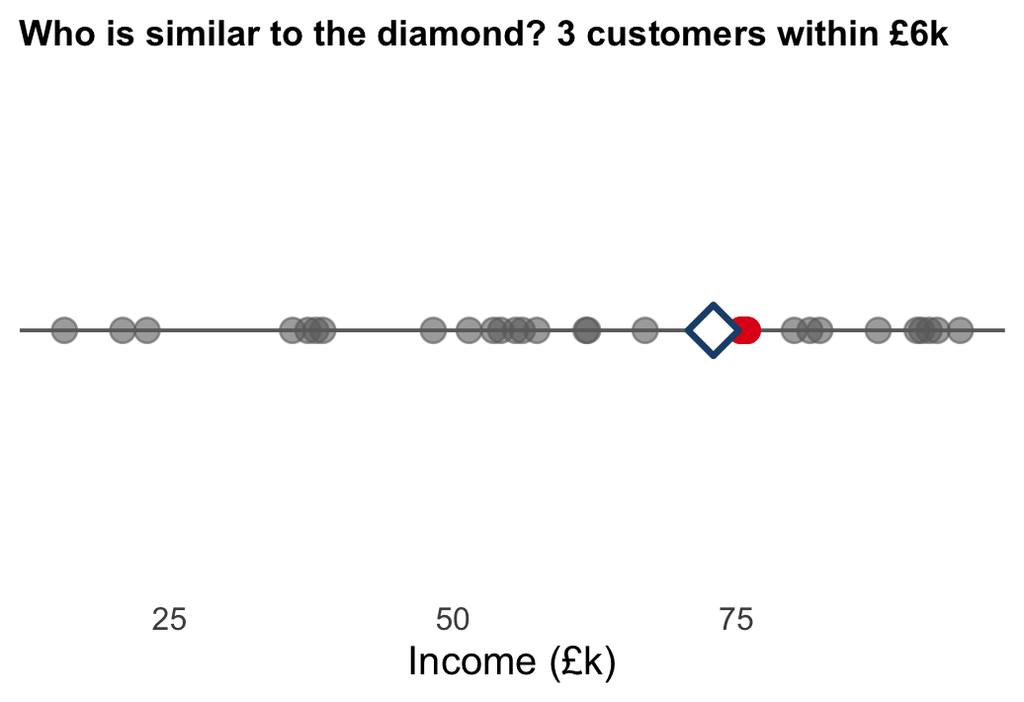

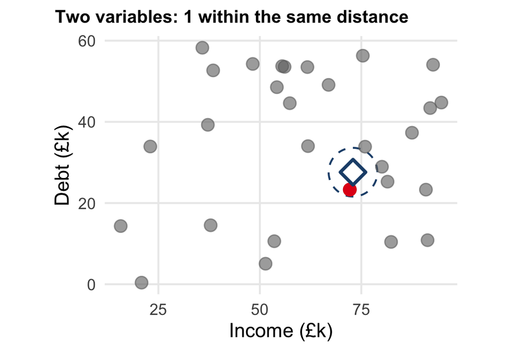

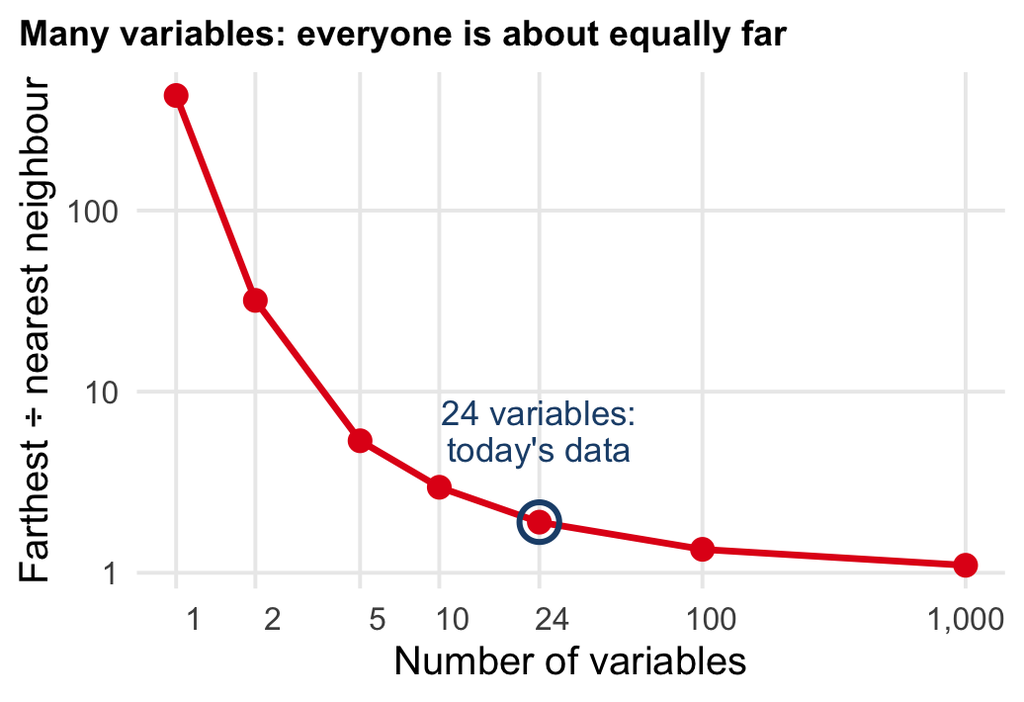

Data become sparse Same 30 customers, one more variable, and the neighbourhood empties.

Distance stops meaning much With 2 variables the farthest customer is 32× as far as the nearest; with 1,000, 1.1×. Bad news for kNN.

And models overfit and slow down So: **squeeze many variables into a few that keep most of the structure**.

# PCA: continuous data

Part I

301 pupils · 24 ability tests · how many things do they really measure?

## The school report: two marks, one number

WhyI · PCAII · MCAWrap-up

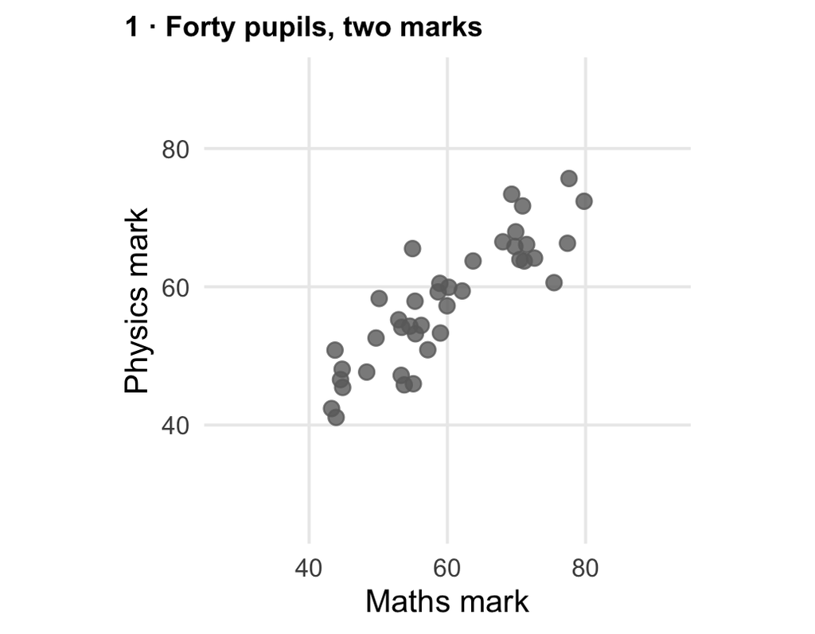

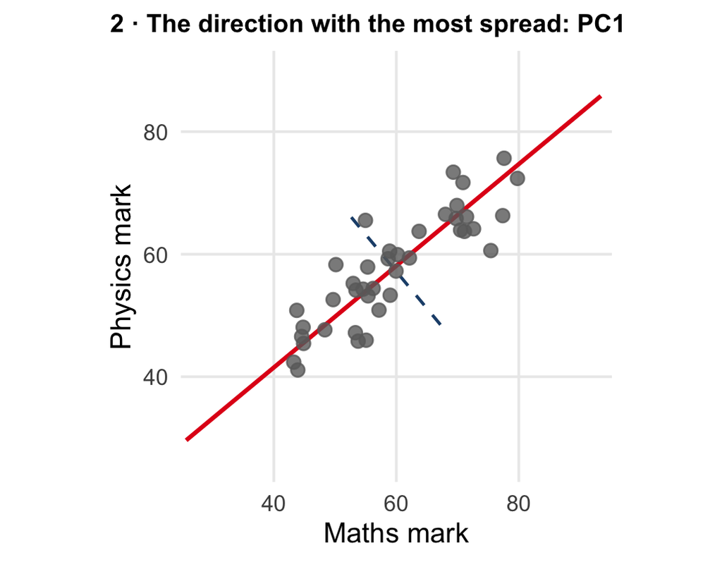

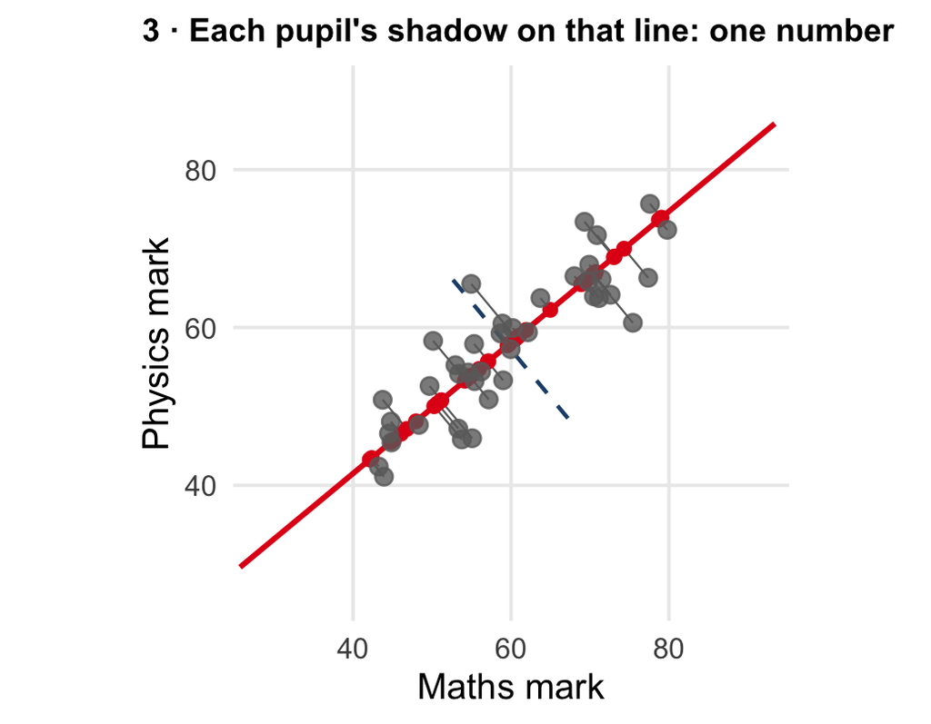

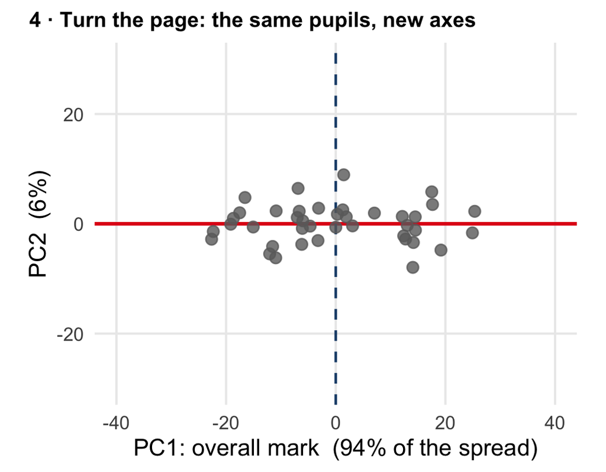

You may write **one** number per pupil on the report. Which?

PC1: where the cloud is longest The line along which pupils differ most. PC2 is at a right angle to it.

A score is a shadow Drop each pupil onto the line. Roughly “maths + physics”: an **overall mark**.

Nothing was lost yet, only turned PC1 holds 94% of the spread. Drop PC2 and you lose 6%: two columns became one.

## Four subjects: reading the loadings

WhyI · PCAII · MCAWrap-up

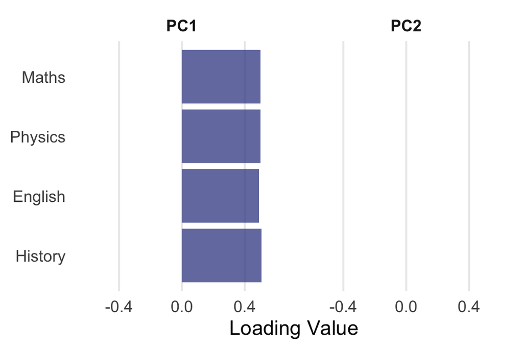

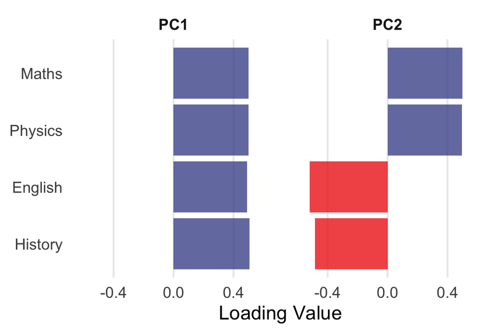

A loading is the weight of a subject in a component blue = positive, red = negative; this is the plot you will read in the lab

PC1 weights all four subjects about equally. Give it a name.

PC1 · a level · 62% Same sign, similar size: a high score means good marks across the board.

PC2 · a contrast · 31% Opposite signs: stronger in sciences *than* in humanities.

How to read any component Which bars are long? Same sign or opposite? What do the long ones share? Then **you** name it.

## Class discussion: two tests that agree

WhyI · PCAII · MCAWrap-up

**Notebook** line 66 the class discussion before the data*30 seconds with your neighbour*

Two IQ tests are strongly correlated. What would you expect PCA to do with them?

**A**Delete one of the two tests, since it adds nothing

**B**Give both a similar weight on the same component

**C**Put each on its own component, so they stay apart

**D**Nothing: PCA only works on uncorrelated variables

**B.** Maths and physics again: tests that move together share a direction, so one component describes both. PCA keeps every variable and **combines** them; it never drops a column. Without correlation there would be nothing to compress.

## Meet the data: 24 ability tests

WhyI · PCAII · MCAWrap-up

**Notebook** lines 68–80 "Load and prepare data": select the tests, then split*run together*

**301**pupils aged 11–16 in two Chicago schools, tested in 1939

**24**tests, `t01` to `t24`: the columns we compress

What is kept `case` (an id), `school` (Pasteur or Grant-White) and the 24 tests. Age, grade and sex are dropped, and two repeat tests (`t25`, `t26`).

| Tests | What they ask | Examples |
| --- | --- | --- |
| `t01`–`t04` | Spatial | cubes, form board, lozenges |
| `t05`–`t09` | Verbal | word meaning, sentence completion |
| `t10`–`t13` | Speed | addition, counting dots, code |
| `t14`–`t19` | Memory | word, number and figure recognition |
| `t20`–`t24` | Reasoning and maths | deduction, series, arithmetic |

The split 240 pupils to train, 61 to test, as in Labs 3–5. PCA is **fitted on the training set only**. The test set is not used again today.

## Explore: do the tests overlap?

WhyI · PCAII · MCAWrap-up

**Notebook** lines 82–97 "Explore relationships": the correlation heatmap and its reflection*run together, then one minute in pairs*

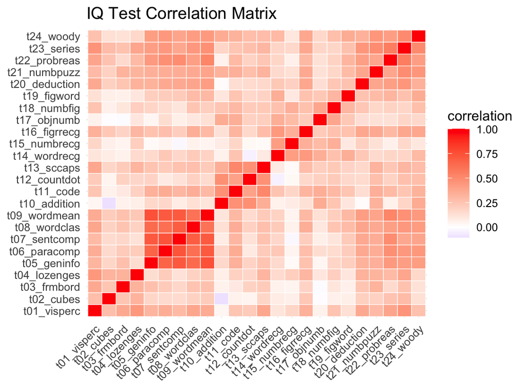

What can you say about this heatmap? What should PC1 look like?

Almost no blue Nearly every pair is positively correlated (0.26 on average): good at one test, good at most. Expect PC1 to be **an overall level**, like the school report.

Darker blocks The verbal tests `t05`–`t09` stand out (0.68 among themselves). The speed tests `t10`–`t13` form a weaker block. Expect the next components to be **contrasts between blocks**.

## Apply PCA: read the recipe

WhyI · PCAII · MCAWrap-up

**Notebook** lines 99–118 "Apply PCA": the recipe, then `bake()`*run together*

pca_recipe <- recipe(school ~ ., data = train_data) |> update_role(case, new_role = "ID") |> step_zv(all_numeric_predictors()) |> step_normalize(all_numeric_predictors()) |> step_pca(all_numeric_predictors(), num_comp = 5, keep_original_cols = TRUE) |> prep()

1. **Same units first.** Otherwise the test with the biggest numbers would be PC1.
2. **The rotation.** Finds the 24 directions, longest first.
3. **Keep five** as new columns `PC1`–`PC5`. We check this choice next.
4. **Do it now**, on the training set. `bake()` then adds the scores.

```
# A tibble: 240 × 4
   case    PC1   PC2    PC3
  <int>  <dbl> <dbl>  <dbl>
1   201 -3.11  1.40  -0.414
2   202  0.384 0.186  0.377
3   203 -0.202 2.63   1.45
4   204 -0.822 0.523 -1.62
# ℹ 236 more rows
```

Read it Pupil 201 has PC1 = -3.1: their shadow on the longest direction, well below the average of 0.

`school ~ .` is not a model Nothing is predicted. It only says which columns count as “predictors”.

## Your turn A: how many components?

Part I · lines 120–174 · in pairs

1. **Lines 122–151:** run both chunks. One bar per component: the share of variance, then the running total.
2. **Lines 155–159:** why might `num_comp = 5` be reasonable? How much do **2, 3 and 5** components explain together? Why is plotting only 2 a risk?
3. **Lines 163–168:** run the scatter of PC1 against PC2.
4. **Lines 172–174:** clusters, outliers, a trend? What is the correlation between PC1 and PC2, and why? What might the plot hide?

How to read the output

```r
eigenvalues            # one row per component
#  PC  percent  cumulative
#   1    0.31        0.31   <- PC1 alone
#   2    0.10        0.40   <- PC1 + PC2 together

cor(pca_data$PC1, pca_data$PC2)   # try it
```

- `percent`: this component’s share of the total spread
- `cumulative`: what you keep if you stop here
- Look for where the bars **flatten**: later components add little each

**Stuck?**

- `pca_fit` not found: run lines 101–118 first
- School report: after turning the page, was any tilt left in the cloud?

## Answers A: variance explained

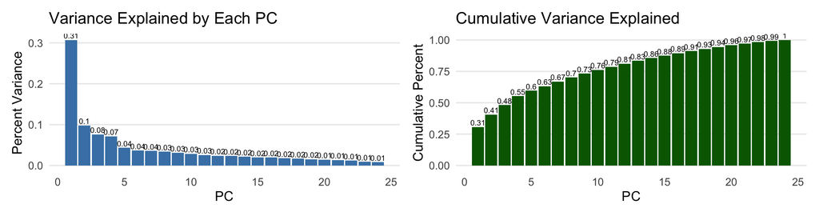

Why five? PC1 stands out with 31%. PC2–PC5 add 10%, 8%, 7%, 4%; after that each adds under 4%. No sharp elbow: **a judgement call**.

2, 3 and 5 components 41%, 48% and 60% of the variance. 24 columns became 5 and kept three fifths of the spread.

Why 2 is risky Two fit on a screen, and show 41%. The other 59% is invisible. Check this number before reading any 2-D plot.

## Answers A: the first two components

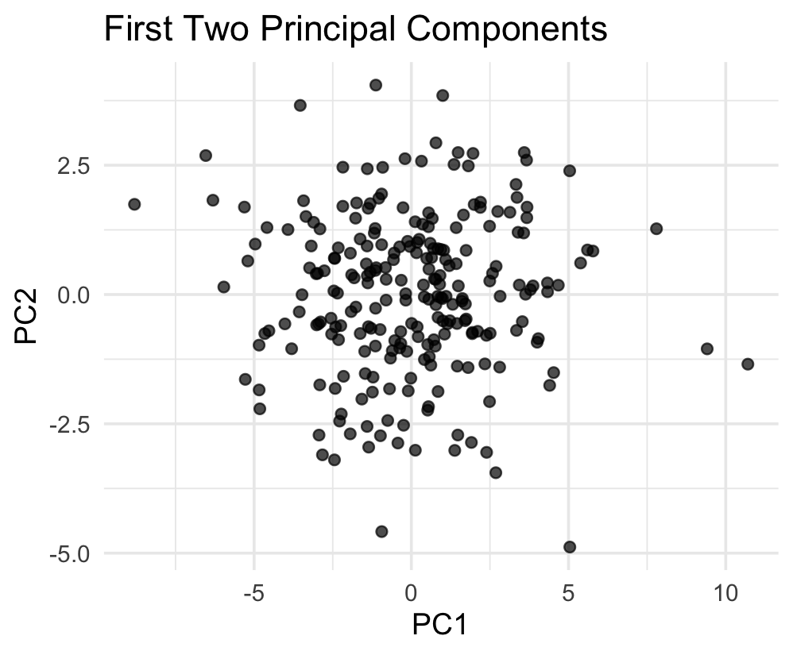

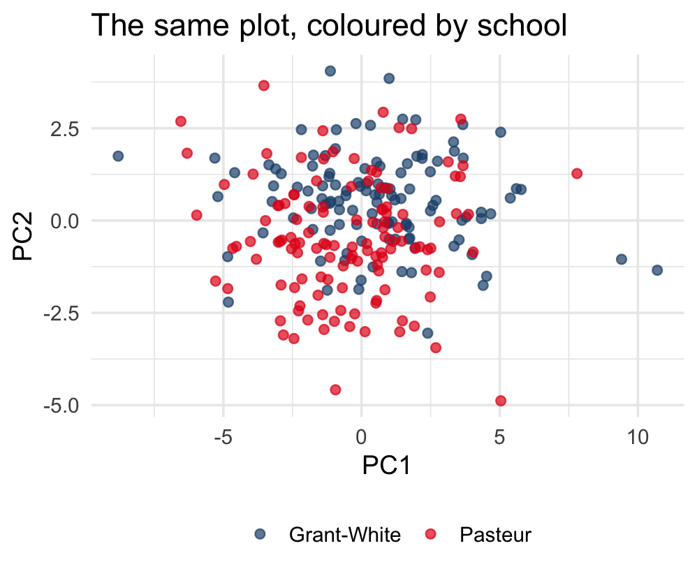

One cloud No clusters and no clear outliers: pupils differ by degree, not by type.

The correlation is exactly 0 By construction: the page was turned until no tilt was left. The missing trend says nothing about the pupils.

What it hides 59% of the variance. Structure in PC3–PC5 cannot be seen here.

And one thing it shows Colour by `school`: Grant-White sits to the upper right. PCA never saw the school.

## Your turn B: what is each component?

Part I · lines 176–214 · in pairs

1. **Lines 178–209:** run the chunk. Three panels, one per component; one bar per test; longest bars at the top.
2. **Line 213:** on **PC1**, what sign do the loadings have, and how similar are their sizes?
3. **Line 214:** which tests sit at opposite ends of **PC2** and **PC3**? What do the tests at each end have in common?
4. Give each component a name of two or three words.

The school-report recipe

- **1 · Which bars are long?** Short bars barely count
- **2 · Same sign or opposite?** One colour: a level. Two colours: a contrast, blue against red
- **3 · What do the long ones share?** Use the table

| `t01`–`t04` | Spatial: shapes, cubes, lozenges |
| --- | --- |
| `t05`–`t09` | Verbal: words, sentences, general information |
| `t10`–`t13` | Speed: addition, code, counting dots |
| `t14`–`t19` | Memory: recognising words, numbers, figures |
| `t20`–`t24` | Reasoning and maths |

**Stuck?**

- Blue or red on its own means nothing: flip every sign of a component and it is the same component

## Answers B: naming the components

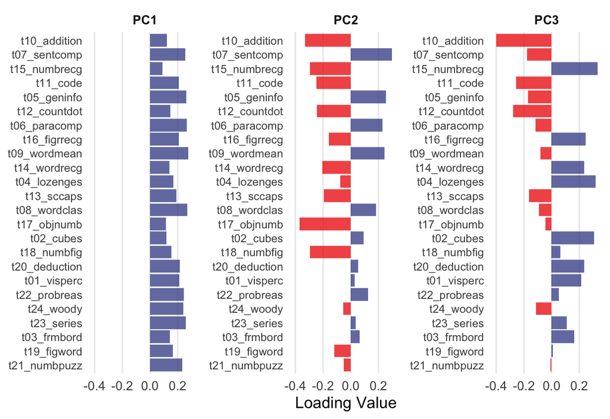

PC1 · overall ability · 31% All 24 positive, from 0.09 to 0.28. The heatmap’s “no blue”. Psychologists call it *g*.

PC2 · words against memory, speed · 10% Blue: sentence completion, general information, word meaning. Red: object–number, addition, number recognition.

PC3 · shapes against speed · 8% Blue: number recognition, lozenges, cubes. Red: addition, counting dots, code. The names are ours; the data only give weights.

# MCA: categorical data

Part II

94,278 people · 19 moral questions · yes or no

## Why not PCA?

WhyI · PCAII · MCAWrap-up

**Notebook** lines 230–233 the class discussion at the start of Part II*one minute with your neighbour*

Why can’t you run PCA on categorical variables? What might “distance” mean instead?

PCA needs arithmetic Means, variances, a longest direction. A test score of 60 is 10 above 50. What is **TV − newspaper**? Or the mean of “yes” and “no”?

Count instead of measure With categories we can still count **who gave which answers together**. That table of co-occurrences is all MCA uses.

Distance = chosen by different people Two answers are **close** when mostly the same people give them. Close means “go together”, not “similar in value”. The notebook calls it chi-square distance.

## What do you watch? A map of answers

WhyI · PCAII · MCAWrap-up

|  | Football | F1 | Bake Off | Strictly |
| --- | --- | --- | --- | --- |
| **A** | y | y | n | n |
| **B** | y | y | n | n |
| **C** | y | y | n | y |
| **D** | y | n | n | n |
| **E** | n | n | y | y |
| **F** | n | n | y | y |
| **G** | n | y | y | y |
| **H** | n | n | y | n |
| **I** | y | y | y | y |
| **J** | n | n | n | n |
| **K** | y | y | n | n |
| **L** | n | n | y | y |

Twelve people, four yes/no questions 8 possible answers

Which answers tend to come from the same people?

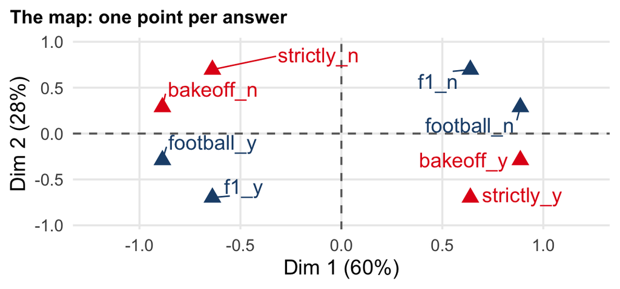

Close = same people `football_y` sits by `f1_y`: the sports fans.

Opposite = rarely together Each `_y` faces its own `_n`. Dim 1: sport against shows.

## Load the data: every answer becomes y or n

WhyI · PCAII · MCAWrap-up

**Notebook** lines 235–252 "Load and prepare ethical norms data"*run together*

norms <- read_csv("data/wvs-wave-7-ethical-norms.csv") |> mutate(across(everything(), ~ as.factor(if_else(.x > median(.x), "y", "n")))) colnames(norms) <- values

1. **Every column**: 19 World Values Survey questions, “is this ever justifiable?”, from 1 (never) to 10 (always).
2. **Above that question’s median: “y”.** Otherwise “n”. A 10-point scale becomes two categories.
3. **Readable names** instead of `Q177`–`Q195`.

Share answering "y" after the median split

premarital sex**49%**

divorce**41%**

stealing property**26%**

terrorism**23%**

“y” is not “supports” For 12 of the 19 questions the median is 1, “never”. There, **y means “anything but never”**: `terrorism_y` is “did not rule it out”.

## Apply MCA: one line

WhyI · PCAII · MCAWrap-up

**Notebook** lines 254–263 "Apply MCA" and the reflection on the supplementary variable*run together*

mca <- MCA(norms, quali.sup = 1, graph = FALSE)

1. **From `FactoMineR`**, not tidymodels: no recipe, no `prep()`.
2. **A table of factors**: 19 columns of y and n.
3. **Column 1 is supplementary**: `cheating_benefits` is left out when the axes are built.
4. **No automatic plot.** We draw our own next.

Why mark a variable as supplementary?

It is placed on the map afterwards The other 18 questions build the axes. `cheating_benefits` is then dropped onto the finished map without shaping it.

A test of the map If the map means something, a question it has never seen should land where we expect. A hold-out for a method with no test score.

## Your turn C: read the map

Part II · lines 265–291 · in pairs

1. **Lines 267–273:** run the biplot. One triangle per answer; green is the supplementary question.
2. **Line 277:** which answers sit at the far ends of **Dim 1** and of **Dim 2**? What do they have in common?
3. **Line 278:** where does `cheating_benefits` land?
4. **Lines 280–287:** run the contribution plot.
5. **Line 291:** which answers contribute most to Dim 1? What do they share?

The TV-map rules

- **Close together:** answers given by the same people
- **Opposite sides:** each question’s `_y` faces its `_n`: read one side of an axis and you know the other
- **Name an axis** by what its two ends have in common
- **Far from the middle:** a rare answer

```r
fviz_contrib(mca, choice = "var", axes = 1, top = 10)
#   choice = "var"   the answers, not the people
#   axes = 1         for Dim 1 (try axes = 2)
# red dashed line:   an equal share for every answer
```

**Stuck?**

- Start with the right-hand side of Dim 1: are the labels `_y` or `_n`?
- Then compare top right with bottom right

## Answers C: the biplot

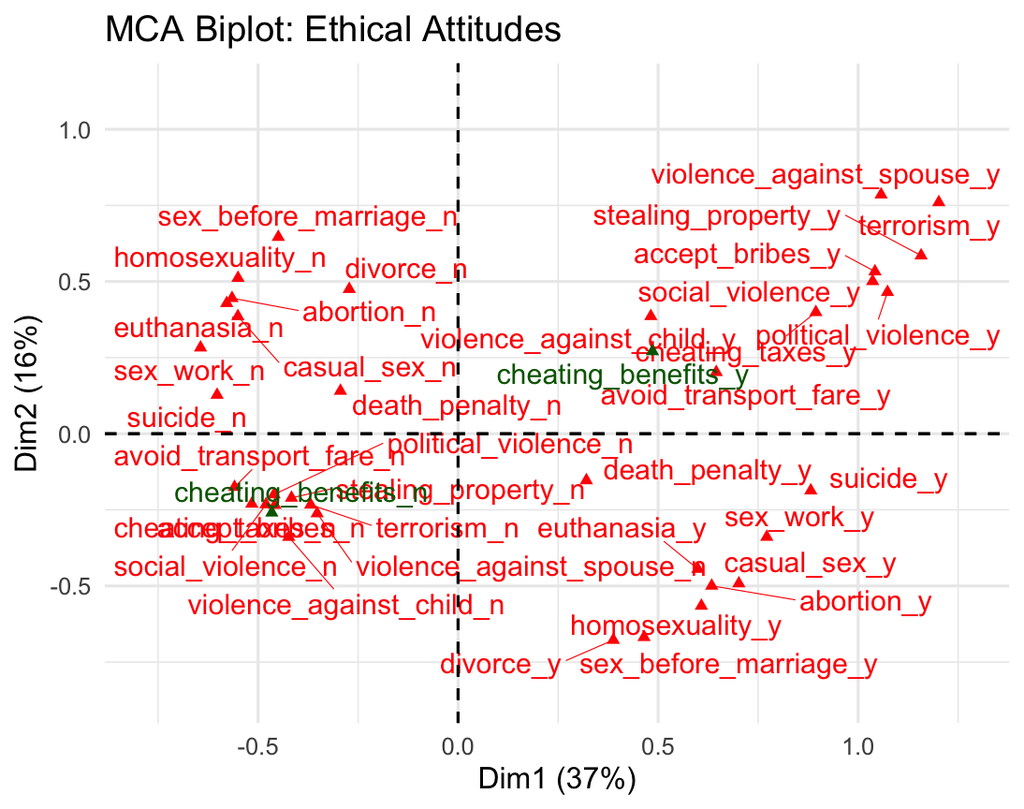

Dim 1 · 37% · how much is justifiable Every `_y` on the right, every `_n` on the left. Like PC1: a **level**.

Dim 2 · 16% · which kind Top right: violence, theft, bribes. Bottom right: divorce, premarital sex, abortion. Like PC2: a **contrast**, harm to others against private life.

The supplementary question fits `cheating_benefits_y` lands right and above the middle, by fare dodging. It never shaped the axes.

## Answers C: who builds Dim 1?

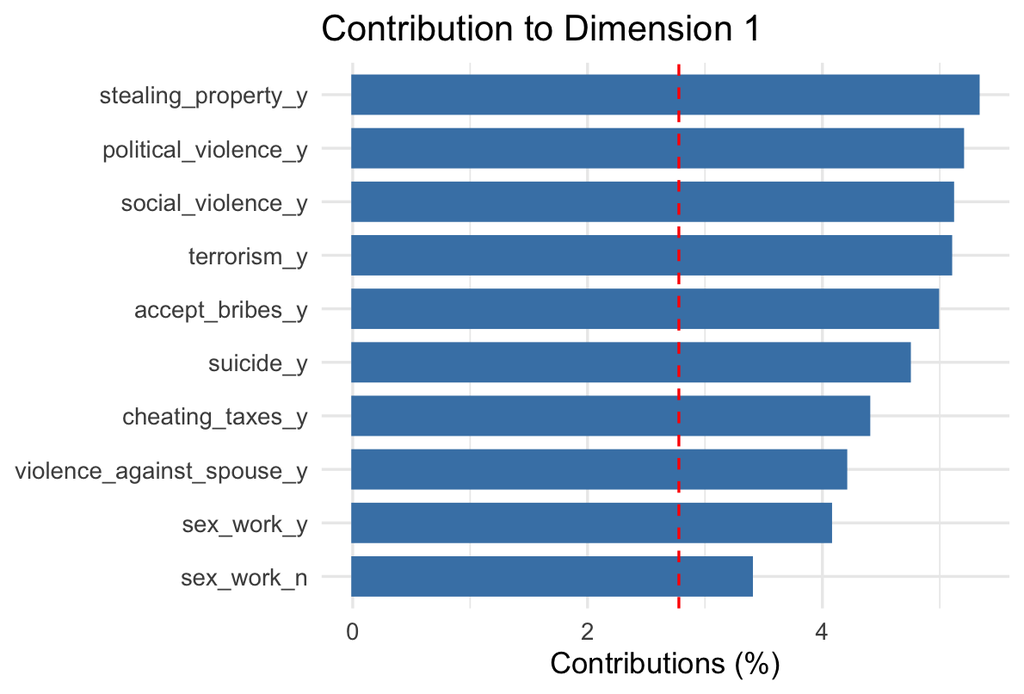

The top eight are all “y” answers Stealing, political violence, social violence, terrorism, bribes, suicide, tax cheating, violence against a spouse. All above the red line (2.8%, an equal share).

What they share Harm and dishonesty, and **rarity**: few people give these answers, so they separate respondents most.

Contributions are MCA’s loadings PCA: which variables have long bars on a component. MCA: which answers contribute most to a dimension. Same question, same reading.

## PCA or MCA?

WhyI · PCAII · MCAWrap-up

|  | PCA | MCA |
| --- | --- | --- |
| **Data** | Numbers with meaningful spacing: test scores, incomes | Categories: yes/no, news source, age group |
| **Built from** | Correlations between variables | Counts of answers given together |
| **Close means** | Similar values | Chosen by the same people |
| **What you read** | Loadings: one bar per variable | The map and contributions: one point per answer |
| **Today** | `step_pca()` in a recipe: 24 tests → 5 components | `MCA()` from `FactoMineR`: 19 questions → 2 dimensions |

The same story twice First axis: a level (overall ability; how much is justifiable). Second: a contrast (verbal against speed; harm against private life).

Both are linear summaries Good for seeing structure and for fewer columns in a later model. The naming is always yours.

## Summary

WhyI · PCAII · MCAWrap-up

**1****Why reduce:** with many variables, data are sparse, distances stop telling rows apart, and models overfit. Real variables overlap, so a few new axes can keep most of the structure

**2****PCA** is the school report: turn the cloud so the first axis runs along its longest direction. Each component has a **share of variance** (how much it keeps) and **loadings** (what it is made of). Same sign: a level. Opposite signs: a contrast. In code: `step_normalize()`, `step_pca()`, `tidy(matrix = "eigenvalues")`, `tidy(matrix = "loadings")`

**3****MCA** is the TV map: one point per answer, close when the same people give them, each y opposite its n. Read the ends of each axis and the **contributions**. In code: `MCA()`, `fviz_mca_biplot()`, `fviz_contrib()`

**Question:** two components show 41% of the test data. Before you trust a pattern in the PC1–PC2 scatter, what would you check?

## Further reading

- The completed notebook goes up after class.
- [*An Introduction to Statistical Learning*](https://www.statlearning.com): 12.1–12.2 (unsupervised learning, principal components). Free PDF.
- [*Tidy Modeling with R*](https://www.tmwr.org): chapter 16 (dimensionality reduction), with `step_pca()` and its relatives.
- [STHDA’s MCA guide](http://www.sthda.com/english/articles/31-principal-component-methods-in-r-practical-guide/114-mca-multiple-correspondence-analysis-in-r-essentials/): every `factoextra` plot for MCA, with code.

## 30 seconds of feedback

[figure not shown]

How was today’s lab? Scan the code, or open forms.gle/i3uobCAaGmkzf1ns7. It takes 30 seconds and changes what next week looks like.